# Research

### Ecology and evolution of plant-animal-microbe interactions

Flying animals play important roles in ecosystems for their dispersal of plant and fungal gametes, spores, and seeds, and in turn, plants and microbes have important effects on host health. My research aims to better understand these interactions and inform strategies for conservation and agriculture. Below you will find details about two of my main interests: (1) pollinator disease ecology and conservation and (2) frugivore gut microbiomes. I hope that this research sheds light on the ecology and evolution of complex interaction networks and may also inform research on novel uses of microbes, such as towards plastic degradation.

#### Effects of pollen diet on bee disease & their underlying mechanisms

Pollinators are essential for ecosystem health, but many species are experiencing population declines. My dissertation research in the [Adler Lab](https://websites.umass.edu/lynnadler/?_gl=1%2A1601mog%2A_gcl_au%2ANjE0NDU5MjgyLjE3Nzk1NjA4OTY.%2A_ga%2AODc3ODI3MDE4LjE3Nzk1NjA4OTc.%2A_ga_21RLS0L7EB%2AczE3ODQzMTc0OTUkbzMkZzAkdDE3ODQzMTc0OTUkajYwJGwwJGgw) focused on bees and their interactions with dietary host plants, pathogens (primarily *Crithidia bombi*), and gut bacteria. I hope my research improves our understanding of factors that influence bee health as well as supports sustainable food production and the livelihoods of farmers.

[Find here our review paper](https://portlandpress.com/emergtoplifesci/article-abstract/4/1/59/221505/Parasite-defense-mechanisms-in-bees-behavior) summarizing our current understanding of how bees defend themselves against pathogens and the role that diet and gut microbes have on immunity and infection outcomes.

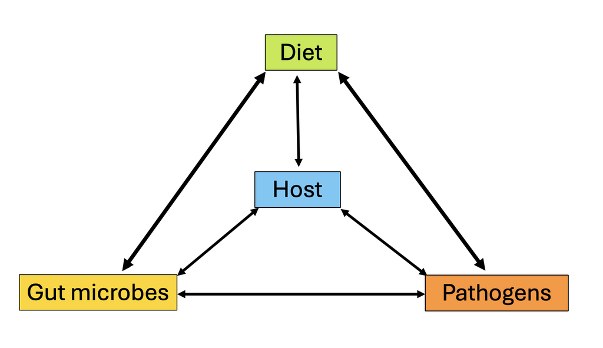

Much of my PhD work stemmed from the finding that pollen from sunflowers and goldenrod (Family: Asteraceae) reduces a gut pathogen in bumble bees ([Giacomini et al., 2018](https://www.nature.com/articles/s41598-018-32681-y?ref=marketbulletin), [LoCascio et al., 2019](https://royalsocietypublishing.org/doi/full/10.1098/rsos.190279)). In collaboration with the [Sadd Lab](https://about.illinoisstate.edu/bmsadd/), I investigated how a sunflower pollen diet impacts the bumble bee immune system as a potential mechanism of the reduced infection. We found that consuming sunflower pollen did not significantly affect activity of the immune enzyme phenoloxidase or hemolymph antibacterial activity. You can read more in our paper: [Fowler et al., 2022, *Philosophical Transactions B*](https://royalsocietypublishing.org/doi/abs/10.1098/rstb.2021.0160).

In addition, I am interested in how diet quality and diversity impact pathogen resistance via changes in the gut microbiome. In collaboration with the [McFrederick Lab](https://melittology.ucr.edu/), I am investigating how a diet of sunflower pollen and parasite infection affects bacterial communities within the gut. These two projects are funded by the USDA National Institute of Food & Agriculture.

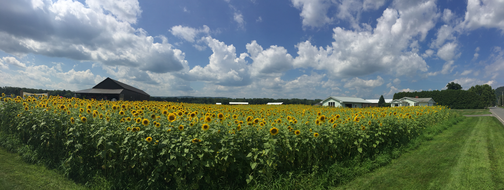

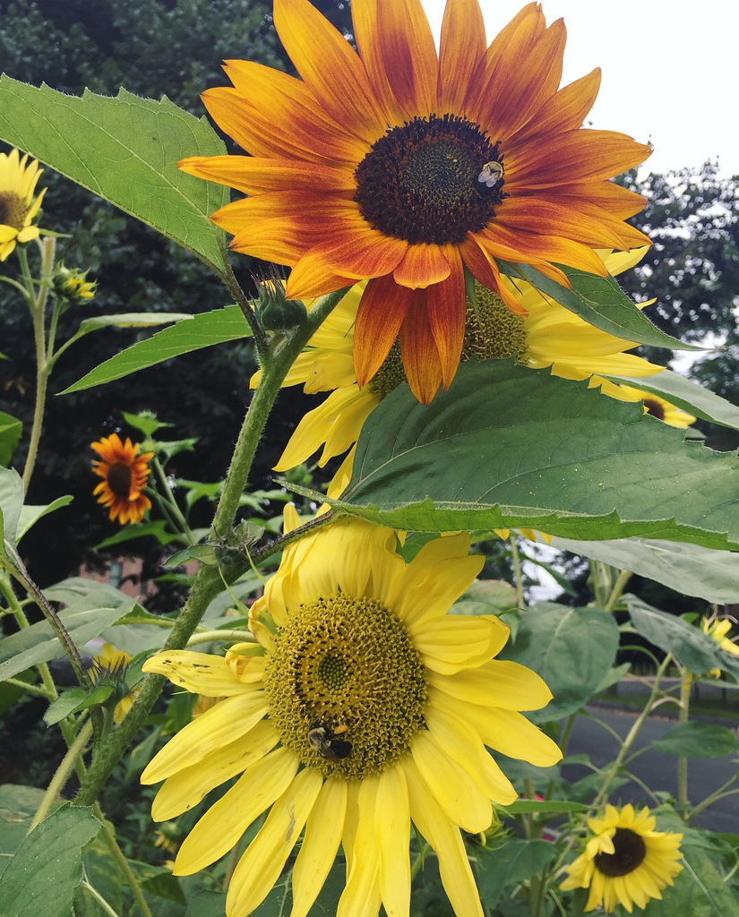

Sunflowers at JM Pasiecnik Farm in Deerfield, MA.

I am also interested in the evolution of social behavior and the costs and benefits associated with group living, particularly in the context of parasite transmission and the evolution of host defense. As part of my dissertation, I tested the effect of pollen diet diversity on gut microbial communities in social (bumble bees; *Bombus impatiens*) and solitary bees (leafcutter bees; *Megachile rotundata*). We compared patterns between species to better understand how the adoption of sociality has impacted microbial symbionts. This project was funded by a Northeast Sustainable Agriculture Research & Education graduate student grant. We found that gut bacterial communities differed significantly between the two bee species, but that pollen diet did not change their compositions in either host. You can read more in our paper: [Fowler et al. 2024, *Microbial Ecology*](https://link.springer.com/article/10.1007/s00248-023-02323-6).

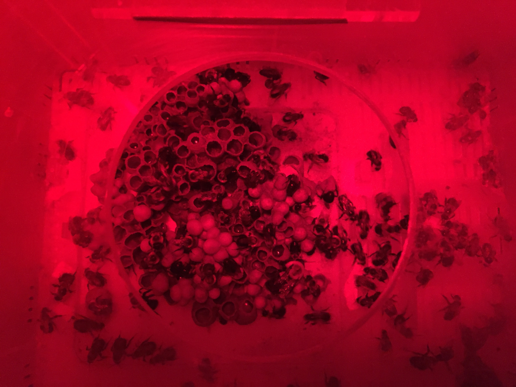

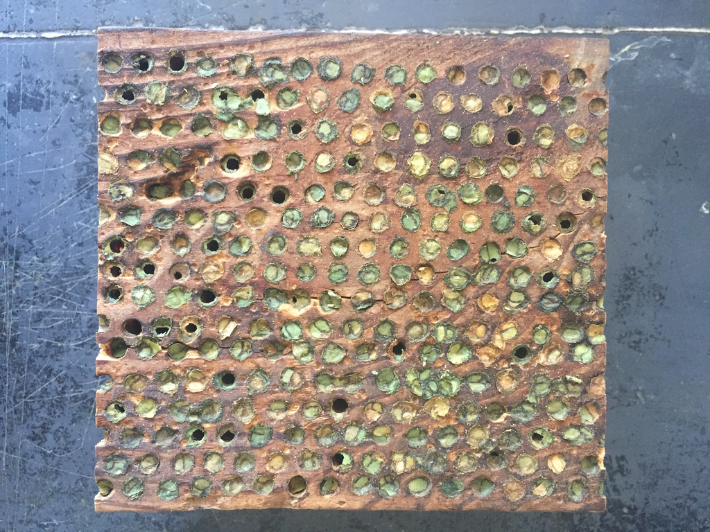

Left: a social bumble bee (*Bombus impatiens*) colony in the lab. Right: a block of individual nests of the alfalfa leafcutter bee (*Megachile rotundata*).

#### Gut microbes in birds and bats

My postdoc research at the Smithsonian Conservation Biology Institute and [Chaverri Lab](https://bowiestate.edu/academics/colleges/college-of-arts-and-sciences/departments/natural-sciences/research/labs/chaverri-research-lab/) at Bowie State University has focused on the gut microbiome (bacterial communities) and mycobiome (fungal communities) of myrtle warblers (*Setophaga coronoata coronata*), which feed on the waxy berries of the wax myrtle and bayberry trees. We aim to better understand the role of gut microbes in the digestion of waxy berries and the birds’ role in dispersing bacteria and fungi that may impact seed germination success and plant health. Below is a poster that summarizes our questions and hypotheses. This work has been in collaboration with many folks at the Smithsonian National Zoo, [Aaron Given and the Kiawah Island Wildlife Group](https://www.kiawahisland.gov/wildlife/about_us/index.php), and [Annie Lindsay at Powdermill Nature Reserve](https://carnegiemnh.org/visit-powdermill/).

I am starting a new project with the Chaverri Lab on the bacterial and fungal communities associated with the fruits of *Piper sancti-felicis* and their fate as they are consumed by and passed through the frugivore, Seba’s short-tailed bat (*Carollia perspicillata*). We are doing field work in Golfito, Costa Rica and conducting a large-scale greenhouse experiment to assess long term seedling microbial communities and health.

[figure not shown]